# EDA - Sistema de recomendación de estrategias deportivas en pádel

Author

Pablo Díaz Merchante

# Introducción y definición de objetivos

- Estructura del dataset
- Distribución de todas las variables
- Comparaciones por jugador
- Relaciones estadísticas entre métricas
- Posibles patrones útiles para el recomendador

# Importación de datos y carga de paquetes

```python
import pandas as pd
import numpy as np
import seaborn as sns
import matplotlib.pyplot as plt

sns.set(style="whitegrid")

# Cargar todas las hojas del Excel

#sheets = pd.read_excel("resumen_juegos.xlsx", sheet_name=None)

#df_list = []

#for name, sheet in sheets.items():
  #sheet["partido"] = name  # Añadimos nombre del partido
  #df_list.append(sheet)

# Unimos todo en un único DataFrame

#df = pd.concat(df_list, ignore_index=True)

#df.head()


df = pd.read_excel("resumen_partido.xlsx")
df.head()
```

|  | jugador | bola dentro | error no forzado | fuerza error | missed | winner | total | bola dentro_% | error no forzado_% | fuerza error_% | missed_% | winner_% | total_% |
| --- | --- | --- | --- | --- | --- | --- | --- | --- | --- | --- | --- | --- | --- |
| 0 | Agustín Tapia | 276.0 | 9.0 | 4.0 | 4.0 | 18.0 | 311.0 | 88.75 | 2.89 | 1.29 | 1.29 | 5.79 | 100 |
| 1 | Alejandro Galán | 255.0 | 13.0 | 7.0 | 9.0 | 21.0 | 305.0 | 83.61 | 4.26 | 2.30 | 2.95 | 6.89 | 100 |
| 2 | Arturo Coello | 269.0 | 6.0 | 8.0 | 3.0 | 18.0 | 304.0 | 88.49 | 1.97 | 2.63 | 0.99 | 5.92 | 100 |
| 3 | Federico Chingotto | 300.0 | 9.0 | 5.0 | 5.0 | 9.0 | 328.0 | 91.46 | 2.74 | 1.52 | 1.52 | 2.74 | 100 |
| 4 | SUMA | 1100.0 | 37.0 | 24.0 | 21.0 | 66.0 | 1248.0 | 352.31 | 11.86 | 7.74 | 6.75 | 21.34 | 400 |

# Diccionario de datos

- jugador: nombre del jugador
- bola dentro: golpes correctos
- error no forzado: fallos sin presión
- missed: fallos
- winner: golpes ganadores
- total: golpes totales

Variables %: cada métrica expresada sobre el total

Se incluye una fila final denominada SUMA, que no pertenece al análisis jugador a jugador

# Limpieza inicial

```python
# Eliminamos filas tipo SUMA

df = df[df["jugador"].str.upper() != "SUMA"]

# Convirtiendo columnas numéricas correctamente

numeric_cols_original = ["bola dentro", "error no forzado", "missed", "winner", "total"]

for col in numeric_cols_original:
  df[col] = pd.to_numeric(df[col], errors="coerce")

df.info()
```

```
<class 'pandas.core.frame.DataFrame'>
Index: 6 entries, 0 to 6
Data columns (total 13 columns):
 #   Column              Non-Null Count  Dtype
---  ------              --------------  -----
 0   jugador             6 non-null      object
 1   bola dentro         6 non-null      float64
 2   error no forzado    6 non-null      float64
 3   fuerza error        6 non-null      float64
 4   missed              6 non-null      float64
 5   winner              6 non-null      float64
 6   total               6 non-null      float64
 7   bola dentro_%       6 non-null      float64
 8   error no forzado_%  6 non-null      float64
 9   fuerza error_%      6 non-null      float64
 10  missed_%            6 non-null      float64
 11  winner_%            6 non-null      float64
 12  total_%             6 non-null      int64
dtypes: float64(11), int64(1), object(1)
memory usage: 672.0+ bytes
```

# Tratamiento de valores nulos

En los datos, el hecho de que un valor sea 0 no es faltante, es algo que tiene sentido. Puede haber 0 errores no forzados y que no sea malo.

```python
# Rellenar valores vacíos con 0
num_cols = ["bola dentro","error no forzado","missed","winner","total","fuerza error"]

for col in num_cols:
    if col in df.columns:
        df[col] = df[col].fillna(0)

# Recalcular porcentajes correctamente
df["bola dentro_%"] = df["bola dentro"] / df["total"]
df["error no forzado_%"] = df["error no forzado"] / df["total"]
df["missed_%"] = df["missed"] / df["total"]
df["winner_%"] = df["winner"] / df["total"]
df["fuerza error_%"] = df["fuerza error"] / df["total"]
```

Crear la lista final de columnas

```python
pct_cols = ["bola dentro_%", "error no forzado_%", "missed_%", "winner_%"]
numeric_cols = numeric_cols_original + pct_cols
```

# Resumen estadístico

```python
df.describe(include="all")
```

|  | jugador | bola dentro | error no forzado | fuerza error | missed | winner | total | bola dentro_% | error no forzado_% | fuerza error_% | missed_% | winner_% | total_% |
| --- | --- | --- | --- | --- | --- | --- | --- | --- | --- | --- | --- | --- | --- |
| count | 6 | 6.000000 | 6.000000 | 6.000000 | 6.000000 | 6.000000 | 6.000000 | 6.000000 | 6.000000 | 6.000000 | 6.000000 | 6.000000 | 6.000000 |
| unique | 6 | NaN | NaN | NaN | NaN | NaN | NaN | NaN | NaN | NaN | NaN | NaN | NaN |
| top | Agustín Tapia | NaN | NaN | NaN | NaN | NaN | NaN | NaN | NaN | NaN | NaN | NaN | NaN |
| freq | 1 | NaN | NaN | NaN | NaN | NaN | NaN | NaN | NaN | NaN | NaN | NaN | NaN |
| mean | NaN | 232.301667 | 8.186667 | 5.305000 | 4.813333 | 14.616667 | 261.851667 | 1.016251 | 0.067785 | 0.043553 | 0.053505 | 0.122385 | 83.333333 |
| std | NaN | 105.599650 | 3.425502 | 2.213176 | 2.300884 | 6.122227 | 123.138670 | 0.332538 | 0.093636 | 0.059560 | 0.090011 | 0.169909 | 40.824829 |
| min | NaN | 18.810000 | 2.870000 | 1.830000 | 2.630000 | 5.200000 | 11.110000 | 0.836066 | 0.019737 | 0.012862 | 0.009868 | 0.027439 | 0.000000 |
| 25% | NaN | 258.500000 | 6.750000 | 4.250000 | 3.250000 | 10.875000 | 304.250000 | 0.882275 | 0.027814 | 0.016241 | 0.013457 | 0.054133 | 100.000000 |
| 50% | NaN | 272.000000 | 9.000000 | 5.500000 | 4.500000 | 17.250000 | 308.000000 | 0.886164 | 0.029293 | 0.021091 | 0.016035 | 0.058544 | 100.000000 |
| 75% | NaN | 275.750000 | 9.187500 | 6.750000 | 5.187500 | 18.000000 | 311.750000 | 0.907841 | 0.039379 | 0.025475 | 0.026338 | 0.066442 | 100.000000 |
| max | NaN | 300.000000 | 13.000000 | 8.000000 | 9.000000 | 21.000000 | 328.000000 | 1.693069 | 0.258326 | 0.164716 | 0.236724 | 0.468047 | 100.000000 |

# Análisis de valores faltantes y duplicados

```python
print("Valores faltantes:")
display(df.isna().sum())

print("Duplicados:")
df.duplicated().sum()
```

```
Valores faltantes:
```

```
jugador               0
bola dentro           0
error no forzado      0
fuerza error          0
missed                0
winner                0
total                 0
bola dentro_%         0
error no forzado_%    0
fuerza error_%        0
missed_%              0
winner_%              0
total_%               0
dtype: int64
```

```
Duplicados:
```

```
np.int64(0)
```

No tenemos valores faltantes en nuestro dataset

# Distribución de variables numéricas (variable a variable)

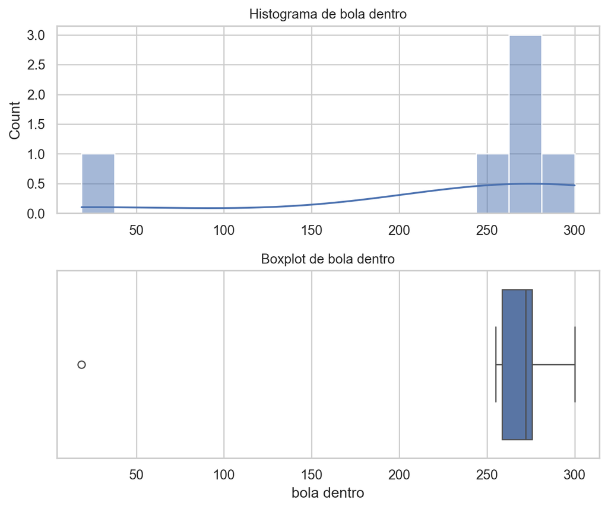

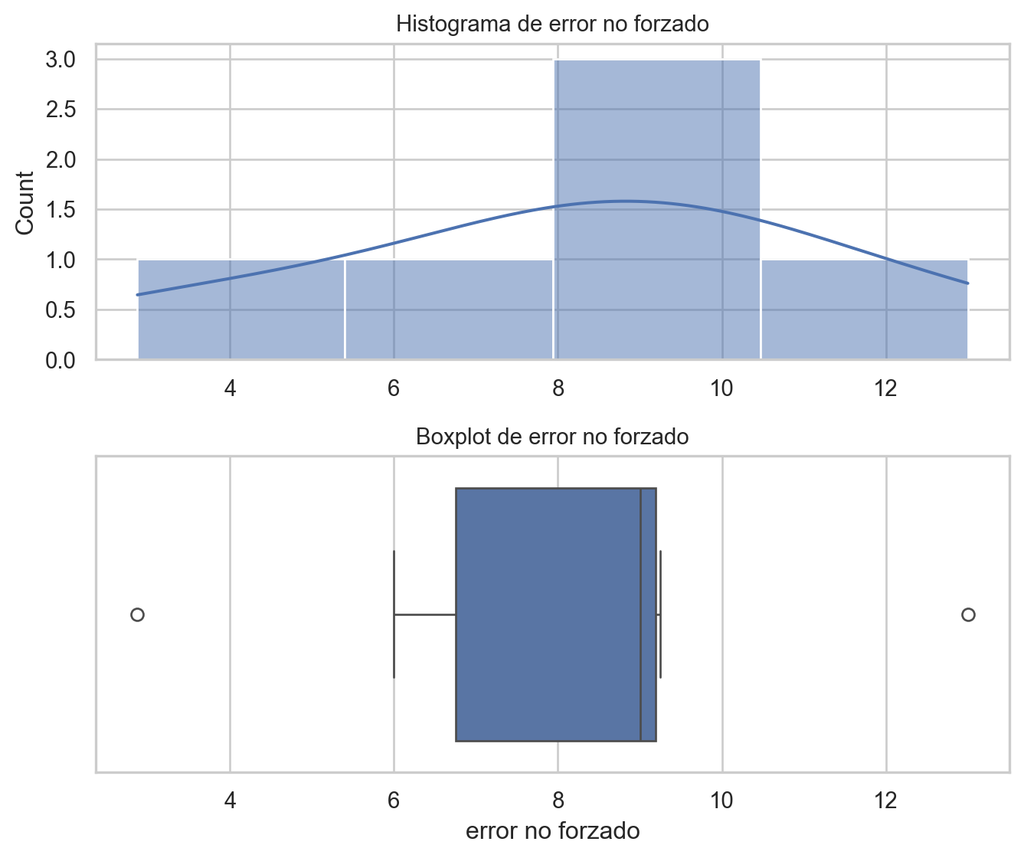

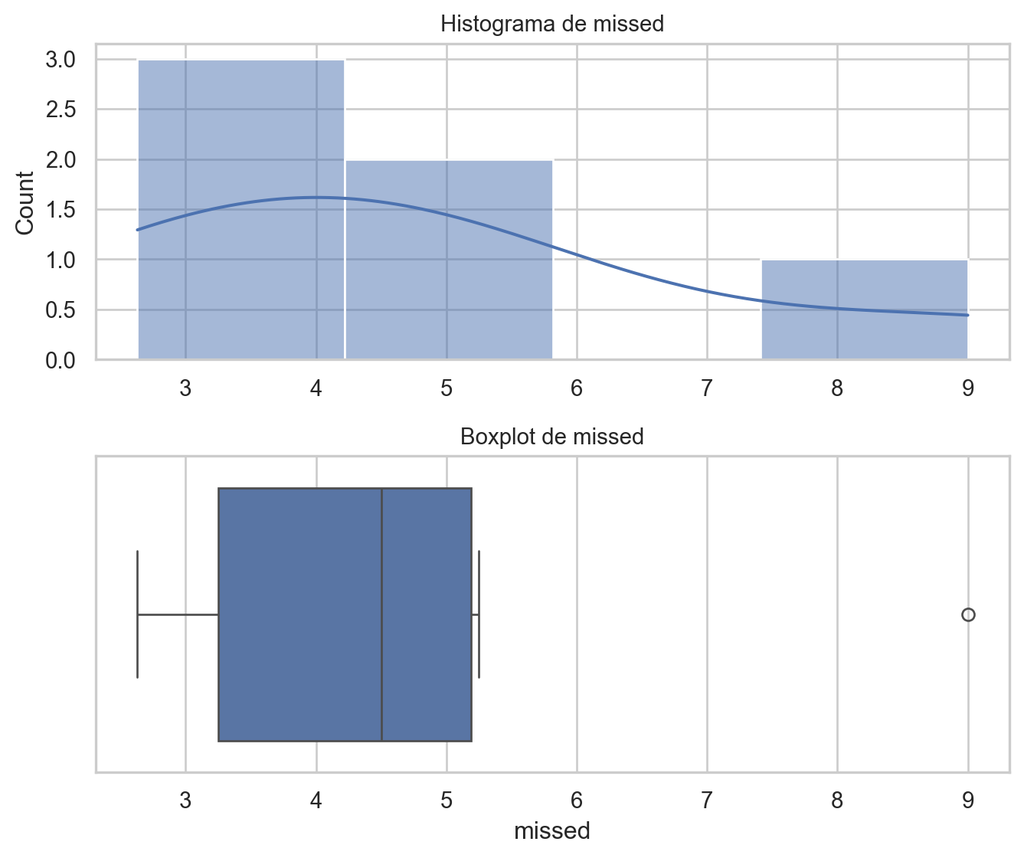

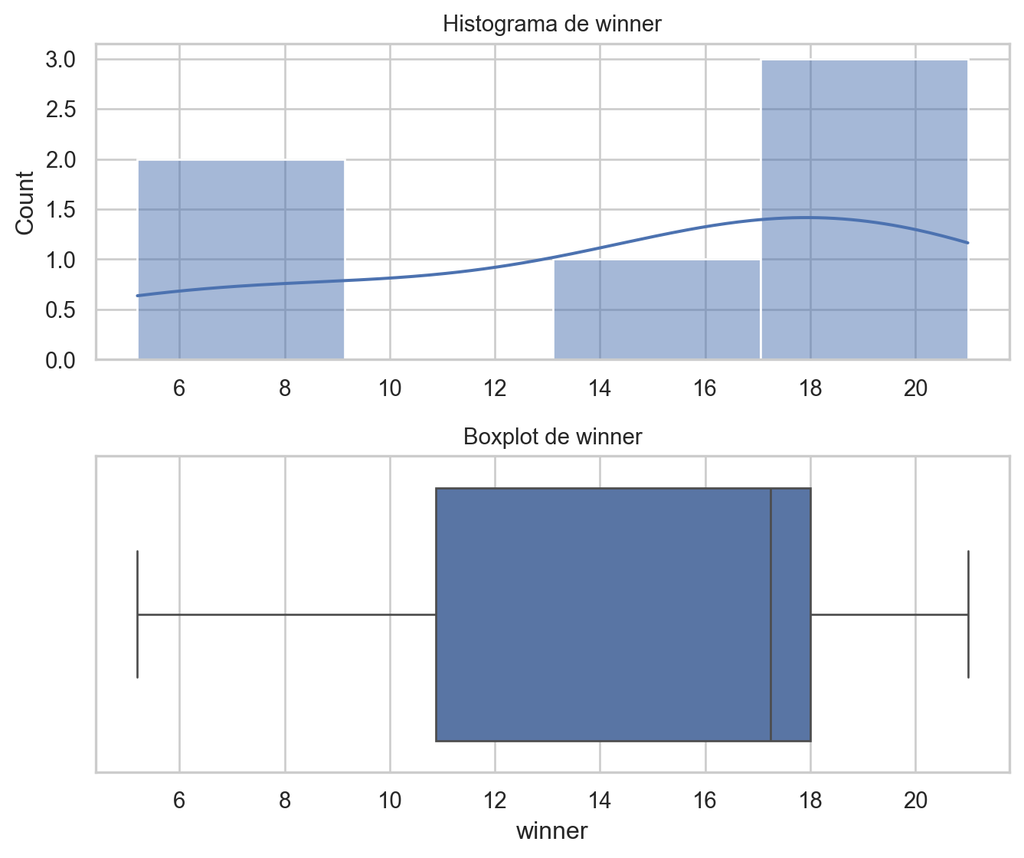

```python
numeric_cols = ['bola dentro', 'error no forzado', 'missed', 'winner']

for col in numeric_cols:
    fig, axes = plt.subplots(2, 1, figsize=(7, 6))  # tamaño perfecto

    # Histograma
    sns.histplot(df[col], kde=True, ax=axes[0])
    axes[0].set_title(f"Histograma de {col}", fontsize=11)
    axes[0].set_xlabel("")  # quita texto extra

    # Boxplot
    sns.boxplot(x=df[col], ax=axes[1])
    axes[1].set_title(f"Boxplot de {col}", fontsize=11)

    plt.tight_layout()
    plt.show()
```

# Distribución de porcentajes

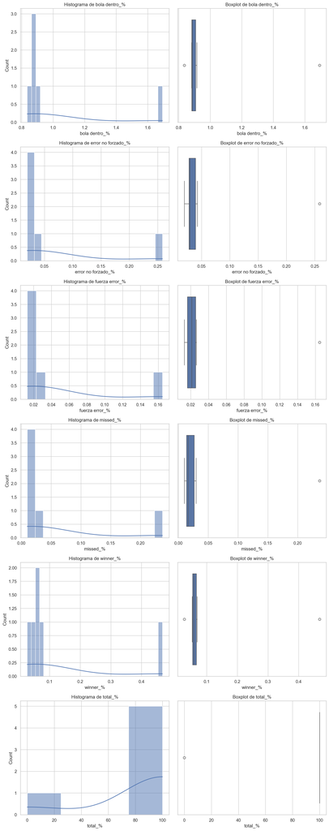

```python
pct_cols = [c for c in df.columns if c.endswith("%")]

fig, axes = plt.subplots(len(pct_cols), 2, figsize=(12, 30))

for i, col in enumerate(pct_cols):
  sns.histplot(df[col], kde=True, ax=axes[i,0])
  axes[i,0].set_title(f"Histograma de {col}")

  sns.boxplot(x=df[col], ax=axes[i,1])
  axes[i,1].set_title(f"Boxplot de {col}")

plt.tight_layout()
plt.show()
```

# Análisis por jugador

## Estadísticas por jugador

```python
df.groupby("jugador")[numeric_cols + pct_cols].mean().round(2)
```

| jugador | bola dentro | error no forzado | missed | winner | bola dentro_% | error no forzado_% | fuerza error_% | missed_% | winner_% | total_% |
| --- | --- | --- | --- | --- | --- | --- | --- | --- | --- | --- |
| Agustín Tapia | 276.00 | 9.00 | 4.00 | 18.0 | 0.89 | 0.03 | 0.01 | 0.01 | 0.06 | 100.0 |
| Alejandro Galán | 255.00 | 13.00 | 9.00 | 21.0 | 0.84 | 0.04 | 0.02 | 0.03 | 0.07 | 100.0 |
| Arturo Coello | 269.00 | 6.00 | 3.00 | 18.0 | 0.88 | 0.02 | 0.03 | 0.01 | 0.06 | 100.0 |
| Federico Chingotto | 300.00 | 9.00 | 5.00 | 9.0 | 0.91 | 0.03 | 0.02 | 0.02 | 0.03 | 100.0 |
| MEDIA | 275.00 | 9.25 | 5.25 | 16.5 | 0.88 | 0.03 | 0.02 | 0.02 | 0.05 | 100.0 |
| STD | 18.81 | 2.87 | 2.63 | 5.2 | 1.69 | 0.26 | 0.16 | 0.24 | 0.47 | 0.0 |

## Barplots comparativos por jugador

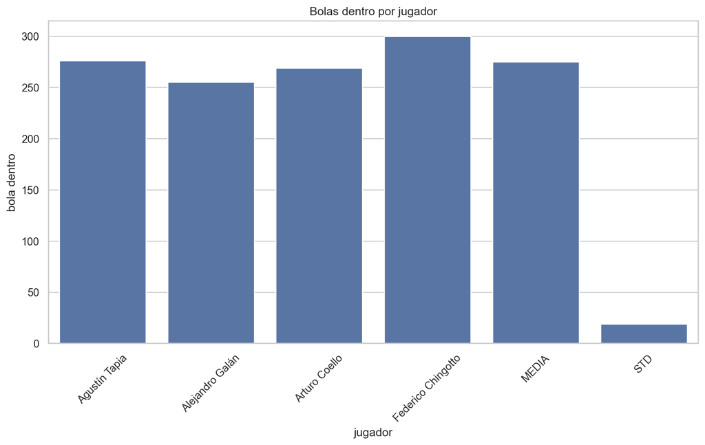

```python
plt.figure(figsize=(12,6))
sns.barplot(data=df, x="jugador", y="bola dentro")
plt.title("Bolas dentro por jugador")
plt.xticks(rotation=45)
plt.show()
```

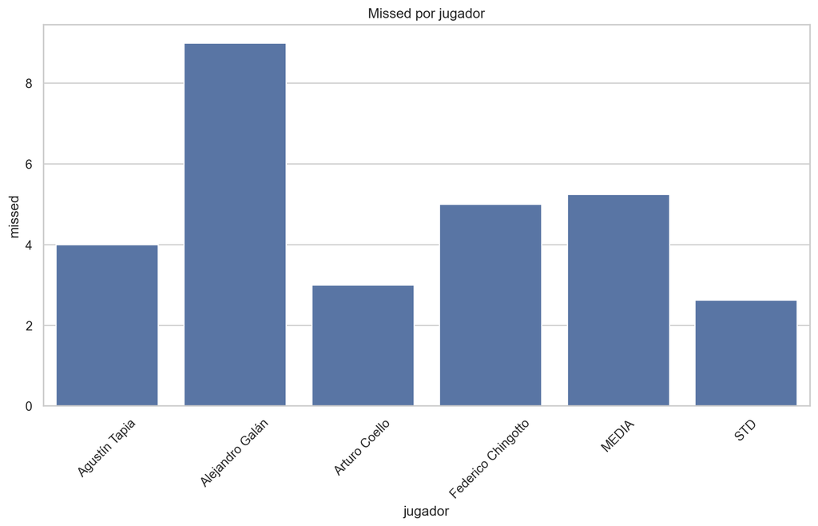

```python
plt.figure(figsize=(12,6))
sns.barplot(data=df, x="jugador", y="missed")
plt.title("Missed por jugador")
plt.xticks(rotation=45)
plt.show()
```

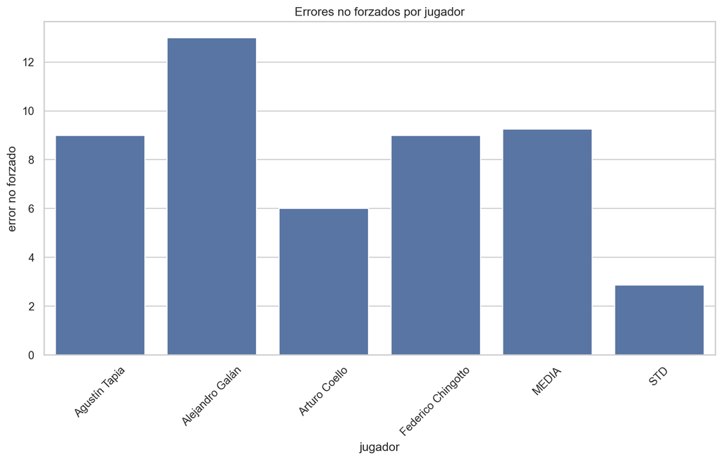

```python
plt.figure(figsize=(12,6))
sns.barplot(data=df, x="jugador", y="error no forzado")
plt.title("Errores no forzados por jugador")
plt.xticks(rotation=45)
plt.show()
```

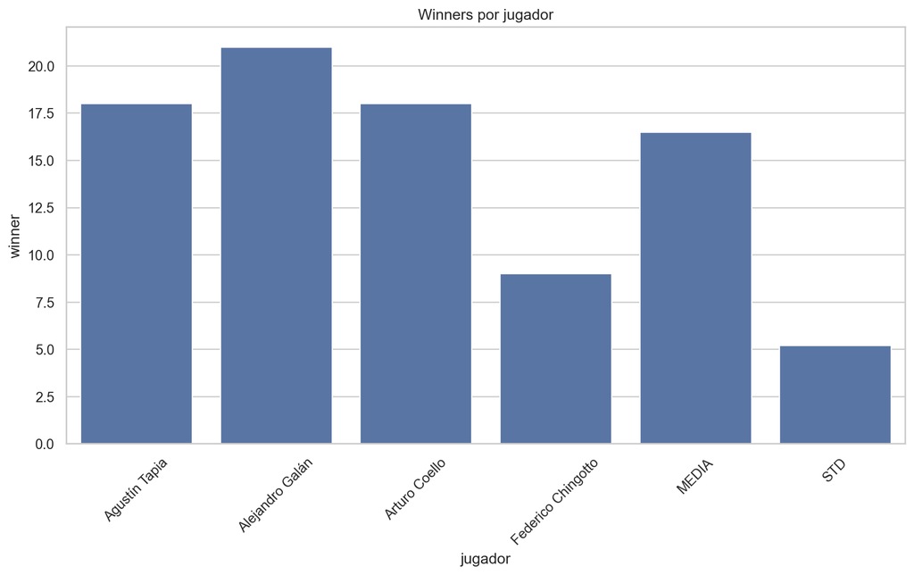

```python
plt.figure(figsize=(12,6))
sns.barplot(data=df, x="jugador", y="winner")
plt.title("Winners por jugador")
plt.xticks(rotation=45)
plt.show()
```

# Análisis comparativo entre jugadores

## Ranking por métrica

```python
for col in pct_cols:
  print(f"\nRanking por {col}")
  display(df[["jugador", col]].sort_values(col, ascending=False).reset_index(drop=True))
```

```
Ranking por bola dentro_%
```

|  | jugador | bola dentro_% |
| --- | --- | --- |
| 0 | STD | 1.693069 |
| 1 | Federico Chingotto | 0.914634 |
| 2 | Agustín Tapia | 0.887460 |
| 3 | Arturo Coello | 0.884868 |
| 4 | MEDIA | 0.881410 |
| 5 | Alejandro Galán | 0.836066 |

```
Ranking por error no forzado_%
```

|  | jugador | error no forzado_% |
| --- | --- | --- |
| 0 | STD | 0.258326 |
| 1 | Alejandro Galán | 0.042623 |
| 2 | MEDIA | 0.029647 |
| 3 | Agustín Tapia | 0.028939 |
| 4 | Federico Chingotto | 0.027439 |
| 5 | Arturo Coello | 0.019737 |

```
Ranking por fuerza error_%
```

|  | jugador | fuerza error_% |
| --- | --- | --- |
| 0 | STD | 0.164716 |
| 1 | Arturo Coello | 0.026316 |
| 2 | Alejandro Galán | 0.022951 |
| 3 | MEDIA | 0.019231 |
| 4 | Federico Chingotto | 0.015244 |
| 5 | Agustín Tapia | 0.012862 |

```
Ranking por missed_%
```

|  | jugador | missed_% |
| --- | --- | --- |
| 0 | STD | 0.236724 |
| 1 | Alejandro Galán | 0.029508 |
| 2 | MEDIA | 0.016827 |
| 3 | Federico Chingotto | 0.015244 |
| 4 | Agustín Tapia | 0.012862 |
| 5 | Arturo Coello | 0.009868 |

```
Ranking por winner_%
```

|  | jugador | winner_% |
| --- | --- | --- |
| 0 | STD | 0.468047 |
| 1 | Alejandro Galán | 0.068852 |
| 2 | Arturo Coello | 0.059211 |
| 3 | Agustín Tapia | 0.057878 |
| 4 | MEDIA | 0.052885 |
| 5 | Federico Chingotto | 0.027439 |

```
Ranking por total_%
```

|  | jugador | total_% |
| --- | --- | --- |
| 0 | Agustín Tapia | 100 |
| 1 | Alejandro Galán | 100 |
| 2 | Arturo Coello | 100 |
| 3 | Federico Chingotto | 100 |
| 4 | MEDIA | 100 |
| 5 | STD | 0 |

# Correlación entre variables

## Heatmap de correlaciones

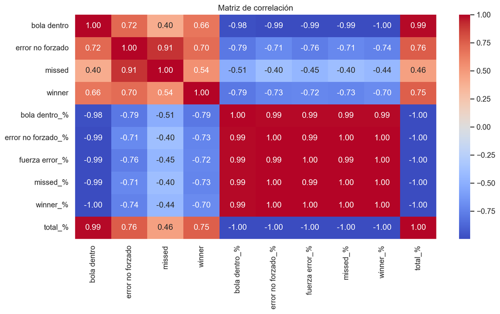

```python
plt.figure(figsize=(12,6))
sns.heatmap(df[numeric_cols + pct_cols].corr(), annot=True, cmap="coolwarm", fmt=".2f")
plt.title("Matriz de correlación")
plt.show()
```

## Pairplot de variables clave

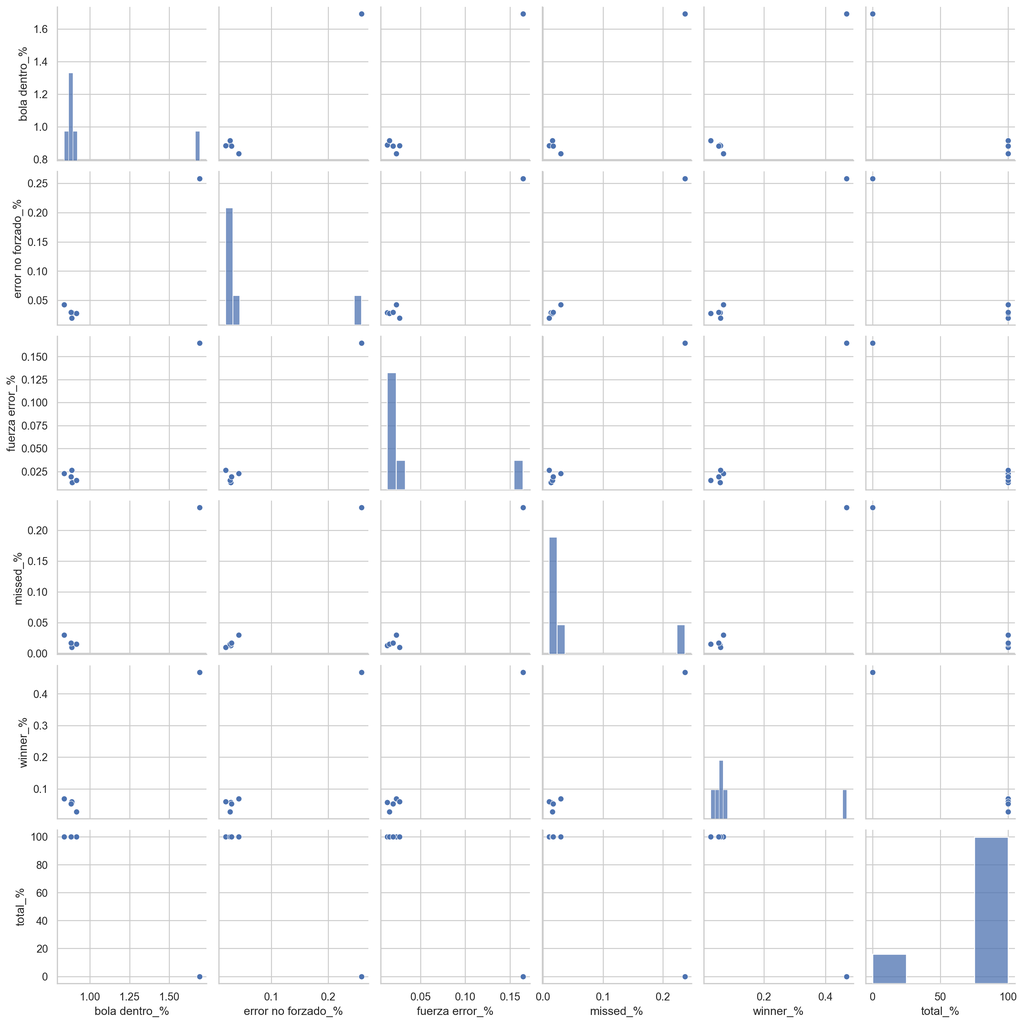

```python
sns.pairplot(df[pct_cols])
plt.show()
```

# Análisis de clúster (descubrimiento de perfiles de jugadores)

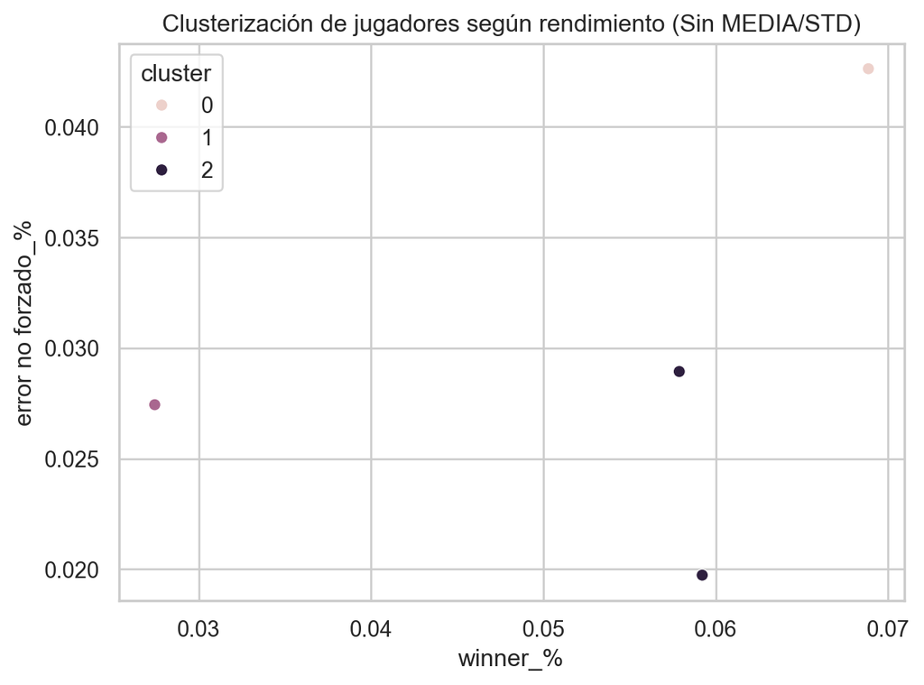

```
              jugador  cluster
0       Agustín Tapia        2
1     Alejandro Galán        0
2       Arturo Coello        2
3  Federico Chingotto        1
```

```python
from sklearn.preprocessing import StandardScaler
from sklearn.cluster import KMeans
import matplotlib.pyplot as plt
import seaborn as sns

# 1. FILTRADO: Excluimos las filas donde 'jugador' sea MEDIA o STD
# El símbolo '~' significa "NO", y '.isin' comprueba si está en la lista.
df_clean = df[~df["jugador"].isin(["MEDIA", "STD"])].copy()

# 2. Preparamos los datos usando el dataframe filtrado (df_clean)
X = df_clean[pct_cols].fillna(0)

# 3. Escalado
scaler = StandardScaler()
X_scaled = scaler.fit_transform(X)

# 4. Clusterización
kmeans = KMeans(n_clusters=3, random_state=42)
# Importante: Asignamos el cluster al dataframe filtrado, no al original completo
df_clean["cluster"] = kmeans.fit_predict(X_scaled)

# 5. Visualización
sns.scatterplot(data=df_clean, x="winner_%", y="error no forzado_%", hue="cluster")
plt.title("Clusterización de jugadores según rendimiento (Sin MEDIA/STD)")
plt.show()

# Mostrar resultados
print(df_clean[["jugador", "cluster"]])
```

## Nuevas Métricas de Rendimiento

Para profundizar en el perfil táctico, calculamos tres índices clave:

Índice de Riesgo (Risk Index): Proporción de errores no forzados sobre el total de errores.

Efectividad Ofensiva: Relación entre Winners y Errores No Forzados. Un valor > 1 indica un jugador “rentable” en ataque.

Capacidad de Presión: Porcentaje de “fuerza error” provocado al rival.

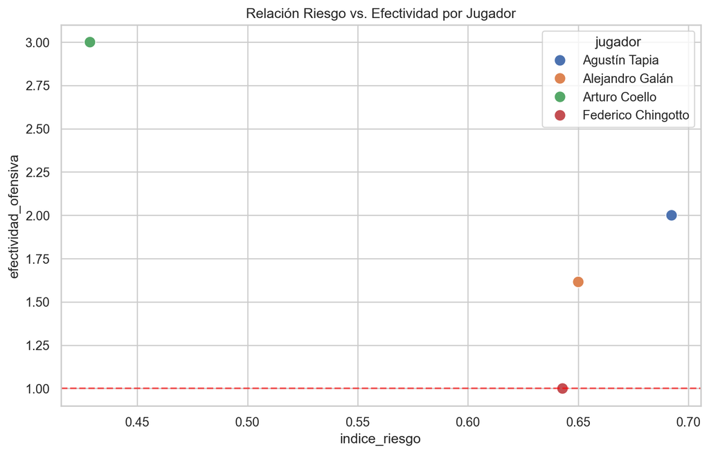

```python
# Cálculo de métricas avanzadas
df_clean['efectividad_ofensiva'] = df_clean['winner'] / df_clean['error no forzado']
df_clean['indice_riesgo'] = df_clean['error no forzado'] / (df_clean['error no forzado'] + df_clean['fuerza error'] + 1e-6)
df_clean['presion_ejercida_%'] = df_clean['fuerza error'] / df_clean['total']

# Visualización de la efectividad vs riesgo
plt.figure(figsize=(10, 6))
sns.scatterplot(data=df_clean, x='indice_riesgo', y='efectividad_ofensiva', hue='jugador', s=100)
plt.axhline(1, color='red', linestyle='--', alpha=0.6) # Línea de rentabilidad
plt.title("Relación Riesgo vs. Efectividad por Jugador")
plt.show()
```

## Análisis por Parejas

El rendimiento en pádel es sinérgico. Agrupamos a los jugadores por sus parejas habituales para comparar el volumen de juego y la eficiencia por lado de la pista.

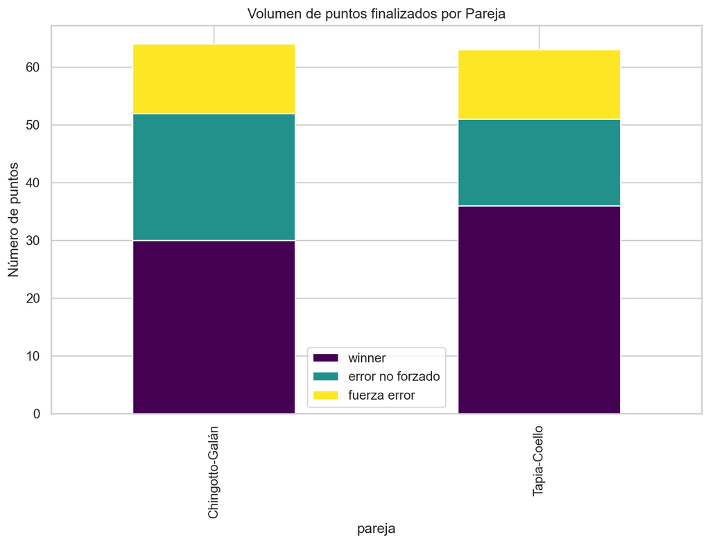

```python
# Definición de parejas (basado en el circuito actual)
parejas_dict = {
    'Agustín Tapia': 'Tapia-Coello',
    'Arturo Coello': 'Tapia-Coello',
    'Alejandro Galán': 'Chingotto-Galán',
    'Federico Chingotto': 'Chingotto-Galán'
}
df_clean['pareja'] = df_clean['jugador'].map(parejas_dict)

# Comparativa de volumen de juego por pareja
df_parejas = df_clean.groupby('pareja')[['winner', 'error no forzado', 'fuerza error']].sum()
df_parejas.plot(kind='bar', stacked=True, figsize=(10,6), colormap='viridis')
plt.title("Volumen de puntos finalizados por Pareja")
plt.ylabel("Número de puntos")
plt.show()
```

## Selección de características para el modelo de recomendación

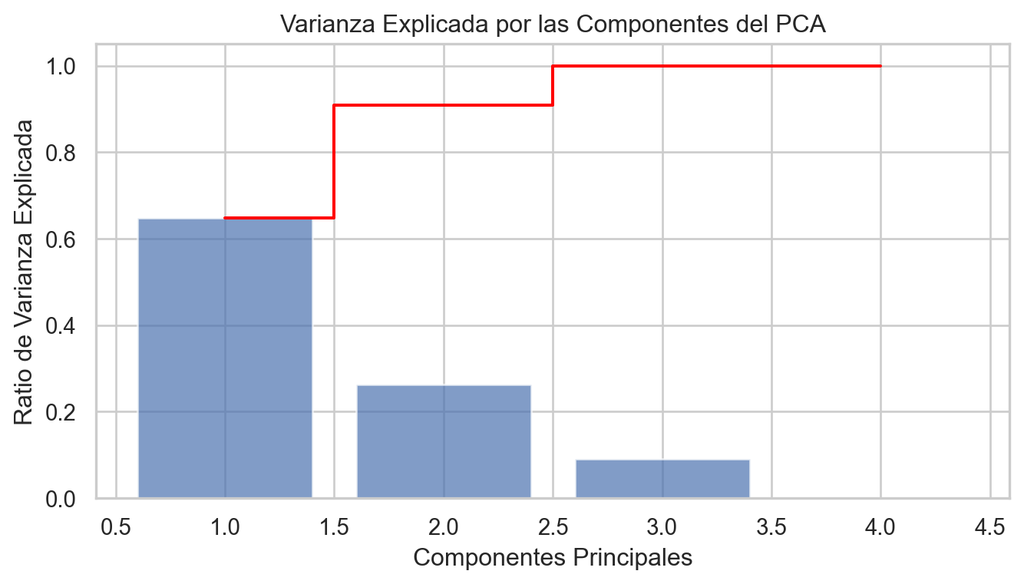

Análisis de Componentes Principales (PCA)

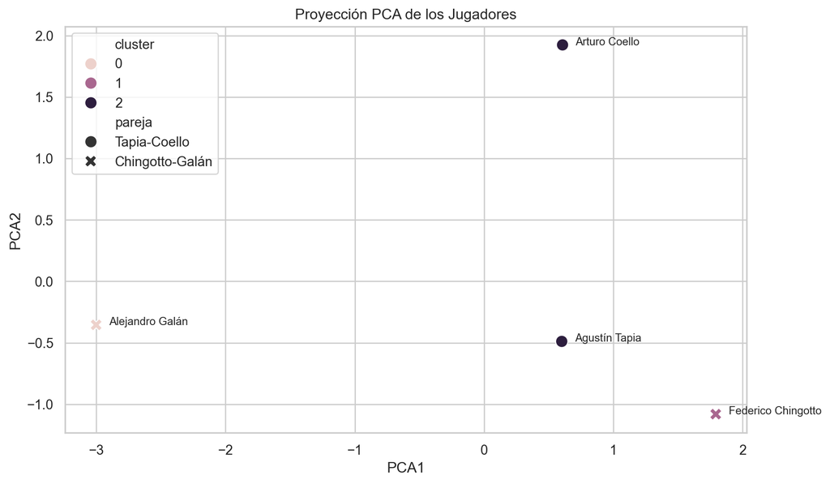

```python
from sklearn.decomposition import PCA
import numpy as np
import matplotlib.pyplot as plt
import seaborn as sns

# Reutilizamos X_scaled del apartado anterior (métricas de jugadores escaladas)
pca = PCA(n_components=None) # CORRECCIÓN: usamos n_components en lugar de n_clusters
pca.fit(X_scaled)

# Varianza explicada
varianza_explicada = pca.explained_variance_ratio_

plt.figure(figsize=(8, 4))
plt.bar(range(1, len(varianza_explicada) + 1), varianza_explicada, alpha=0.7, align='center')
plt.step(range(1, len(varianza_explicada) + 1), np.cumsum(varianza_explicada), where='mid', color='red')
plt.ylabel('Ratio de Varianza Explicada')
plt.xlabel('Componentes Principales')
plt.title('Varianza Explicada por las Componentes del PCA')
plt.show()

# Aplicamos PCA con 2 componentes para visualizar
pca_2 = PCA(n_components=2)
X_pca = pca_2.fit_transform(X_scaled)
df_clean['PCA1'] = X_pca[:, 0]
df_clean['PCA2'] = X_pca[:, 1]

plt.figure(figsize=(10, 6))
sns.scatterplot(data=df_clean, x='PCA1', y='PCA2', hue='cluster', style='pareja', s=100)
for i in range(df_clean.shape[0]):
    plt.text(df_clean['PCA1'].iloc[i]+0.1, df_clean['PCA2'].iloc[i], df_clean['jugador'].iloc[i], fontsize=9)
plt.title("Proyección PCA de los Jugadores")
plt.show()
```

## clustering por juegos

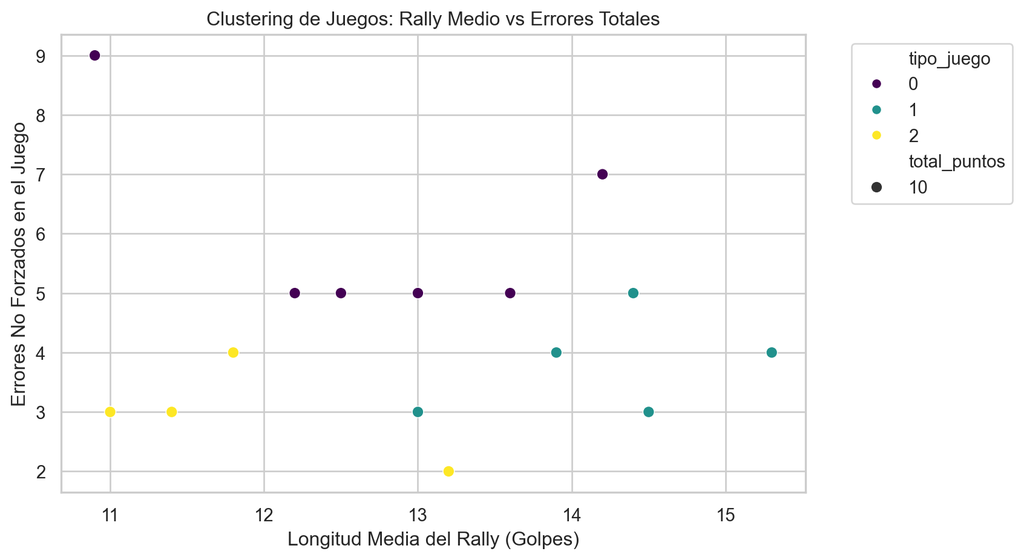

| tipo_juego | juego | total_puntos | winners_totales | errores_totales | rally_medio |
| --- | --- | --- | --- | --- | --- |
| 0 | 9.83 | 10.0 | 4.17 | 6.0 | 12.73 |
| 1 | 7.40 | 10.0 | 8.00 | 3.8 | 14.22 |
| 2 | 6.00 | 10.0 | 4.25 | 3.0 | 11.85 |

```python
from sklearn.cluster import KMeans
from sklearn.preprocessing import StandardScaler
import pandas as pd
import numpy as np
import matplotlib.pyplot as plt
import seaborn as sns

# --- SIMULACIÓN DE DATOS DE PUNTOS ---
# Sustituye esto por: df_puntos = pd.read_excel("resumen_partido.xlsx", sheet_name="puntos")
np.random.seed(42)
n_puntos = 150
df_puntos = pd.DataFrame({
    'juego': np.repeat(np.arange(1, 16), 10), # 15 juegos, 10 puntos por juego aprox
    'winner': np.random.randint(0, 2, n_puntos),
    'error_no_forzado': np.random.randint(0, 2, n_puntos),
    'rally_length': np.random.randint(3, 25, n_puntos) # Número de golpes por punto
})
# --------------------------------------

# 1. Agregamos las estadísticas por juego
df_juegos = df_puntos.groupby('juego').agg(
    total_puntos=('juego', 'count'),
    winners_totales=('winner', 'sum'),
    errores_totales=('error_no_forzado', 'sum'),
    rally_medio=('rally_length', 'mean')
).reset_index()

# 2. Escalamos las variables
scaler_juegos = StandardScaler()
X_juegos = scaler_juegos.fit_transform(df_juegos[['total_puntos', 'winners_totales', 'errores_totales', 'rally_medio']])

# 3. Clustering (Buscamos 3 tipos de juegos: ej. Rápidos, Disputados, Erráticos)
kmeans_juegos = KMeans(n_clusters=3, random_state=42)
df_juegos['tipo_juego'] = kmeans_juegos.fit_predict(X_juegos)

# 4. Visualización
plt.figure(figsize=(9, 5))
sns.scatterplot(data=df_juegos, x='rally_medio', y='errores_totales', hue='tipo_juego', size='total_puntos', sizes=(50, 250), palette='viridis')
plt.title("Clustering de Juegos: Rally Medio vs Errores Totales")
plt.xlabel("Longitud Media del Rally (Golpes)")
plt.ylabel("Errores No Forzados en el Juego")
plt.legend(bbox_to_anchor=(1.05, 1), loc='upper left')
plt.tight_layout()
plt.show()

# Mostramos el perfil de cada clúster
display(df_juegos.groupby('tipo_juego').mean().round(2))
```